# Survival Anlaysis

LEE EUNJI

2019년 3월 16일

# Relationship between tumor histology and time to tumor relapse

## 1. Introduction

There are two types of histology. One is favorable and the other is unfavorable. It is considered that times to tumor relapse may be different according to the types of histology. So, the purpose of this paper is to assess the relationship between the tumor histology and compare the impact on times to tumor relapse.

According to the data set, there are 9 variables.

[output not shown]

- Example Of Dataset

```
##        trel       tsur relaps dead study stage histol        age tumdiam
## 1 0.1286790  1.5304586      1    1     3     1      0 2.08333333       9
## 2 0.4845996 14.6830938      1    0     3     1      0 3.00000000      14
## 3 0.3394935  0.3696099      1    1     3     1      1 0.08333333       7
## 4 0.3312799  0.7967146      1    1     3     1      1 4.66666667      13
## 5 0.1259411  0.7775496      1    1     3     1      1 0.33333333       9
## 6 1.7932923  2.9404517      1    1     3     1      0 1.91666667       8
```

## 2. Method

### Getting KM estiamtors and a hazard plot

To set a method to construct an analysis on the relationship between the tumor histology and relapse time, you should get KM estimators and draw a plot.

- KM estimators

```r
library(survival)
wilms_km <- survfit(Surv(trel, relaps) ~ histol, conf.type = "log-log", data = wilms)
wilms_km
```

```
## Call: survfit(formula = Surv(trel, relaps) ~ histol, data = wilms,
##     conf.type = "log-log")
##
##             n events median 0.95LCL 0.95UCL
## histol=0 1687    475     NA      NA      NA
## histol=1  286    194   1.14   0.934    1.46
```

- Plot

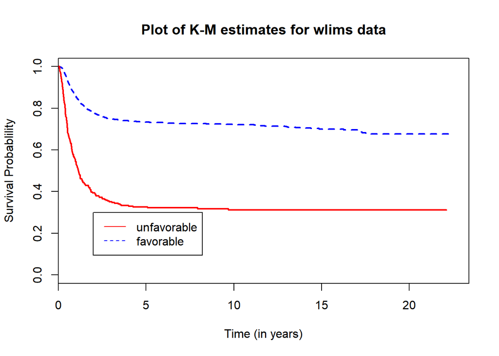

```r
plot(wilms_km, lwd = c(2, 2), lty = c(2, 1), col = c("blue", "red"), xlab = "Time (in years)",         ylab = "Survival Probablility", main = "Plot of K-M estimates for wlims data")
legend(2, .3, c("unfavorable", "favorable"), lty = c(1, 2), col = c("red", "blue"))
```

According to the plot above, it seems that there is a difference between the tumor histology. To confirm more accurately whether there is a difference between the tumor histology or not, the log rank test should be conducted.

### Conduct a Log Rank Test

```r
wilms_logrank <- survdiff(Surv(trel, relaps) ~ histol, data = wilms)
wilms_logrank
```

```
## Call:
## survdiff(formula = Surv(trel, relaps) ~ histol, data = wilms)
##
##             N Observed Expected (O-E)^2/E (O-E)^2/V
## histol=0 1687      475    600.9      26.4       261
## histol=1  286      194     68.1     232.9       261
##
##  Chisq= 261  on 1 degrees of freedom, p= <2e-16
```

H<sub>0</sub> : S<sub>1</sub>(t)=S<sub>0</sub>(t)  
H<sub>1</sub> : S<sub>1</sub>(t)=[S<sub>0</sub>(t)]<sup>c</sup> where c is not equal to 1  
Because p-value (2e-16) is lower than 0.05, H<sub>0</sub> can be rejected. Therefore, it is concluded that there is a difference between the tumor histology.

**A cox model and an AFT model are needed to analyze more about this difference.**

### Conduct a Cox Model

- model  
  $\lambda(t|Z_1, Z_2, Z_3, Z_4, Z_5) = \lambda_0 (t)exp(\beta_1 Z_1 + \beta_2 Z_2 + \beta_3 Z_3 + \beta_4 Z_4 + \beta_5 Z_5 )$

```r
wilms_cox <- coxph(Surv(trel, relaps) ~ histol + as.factor(stage) + as.factor(study) + age +                   tumdiam , data=wilms)
wilms_cox
```

```
## Call:
## coxph(formula = Surv(trel, relaps) ~ histol + as.factor(stage) +
##     as.factor(study) + age + tumdiam, data = wilms)
##
##                        coef exp(coef)  se(coef)      z      p
## histol             1.007457  2.738627  0.086946 11.587 <2e-16
## as.factor(stage)2  1.238772  3.451372  0.110259 11.235 <2e-16
## as.factor(stage)3  1.455917  4.288414  0.113038 12.880 <2e-16
## as.factor(stage)4  1.776586  5.909645  0.121077 14.673 <2e-16
## as.factor(study)4 -0.079392  0.923678  0.080289 -0.989 0.3227
## age                0.026938  1.027304  0.013974  1.928 0.0539
## tumdiam            0.011568  1.011635  0.009876  1.171 0.2414
##
## Likelihood ratio test=540.1  on 7 df, p=< 2.2e-16
## n= 1973, number of events= 669
```

According to cox model, it seems that histology and stage have valid effect on hazard. To check whether the proportional hazard assumption is true or not, conduct a schoenfeld residual test.

- Schoenfeld residual test

```r
schf_resi <- cox.zph(wilms_cox,transform = 'km')
schf_resi
```

```
##                       rho  chisq        p
## histol            -0.0906  5.401 2.01e-02
## as.factor(stage)2 -0.0175  0.206 6.50e-01
## as.factor(stage)3 -0.0390  1.045 3.07e-01
## as.factor(stage)4 -0.1030  7.383 6.58e-03
## as.factor(study)4  0.0971  6.746 9.40e-03
## age                0.1647 18.733 1.50e-05
## tumdiam           -0.0306  0.607 4.36e-01
## GLOBAL                 NA 39.594 1.51e-06
```

### Conduct an AFT Model

- model  
  S<sub>1</sub>(t|Z) = S<sub>0</sub>($\phi$(Z<sub>i</sub>)t) where $\phi$(Z) = exp($\beta$Z)  
  $logT = \beta_1 Z_1 + \beta_2 Z_2 + \beta_3 Z_3 + \beta_4 Z_4 + \beta_5 Z_5 +\sigma W )$

```r
wilms_aft <- survreg(Surv(trel, relaps) ~ histol + as.factor(stage) + as.factor(study) + age + tumdiam , dist = 'exponential', data = wilms)
summary(wilms_aft)
```

```
##
## Call:
## survreg(formula = Surv(trel, relaps) ~ histol + as.factor(stage) +
##     as.factor(study) + age + tumdiam, data = wilms, dist = "exponential")
##                     Value Std. Error      z      p
## (Intercept)        4.7221     0.1462  32.29 <2e-16
## histol            -1.2821     0.0868 -14.77 <2e-16
## as.factor(stage)2 -1.2244     0.1093 -11.20 <2e-16
## as.factor(stage)3 -1.8159     0.1130 -16.07 <2e-16
## as.factor(stage)4 -2.0388     0.1205 -16.92 <2e-16
## as.factor(study)4 -0.3838     0.0808  -4.75  2e-06
## age               -0.0433     0.0141  -3.07 0.0022
## tumdiam           -0.0104     0.0101  -1.03 0.3026
##
## Scale fixed at 1
##
## Exponential distribution
## Loglik(model)= -2394.7   Loglik(intercept only)= -2758.7
##  Chisq= 727.91 on 7 degrees of freedom, p= 6.6e-153
## Number of Newton-Raphson Iterations: 5
## n= 1973
```

According to the output in R, the p-value of tumdiam is larger than 0.05. That is, tumdiam does not seem to have valid effect on hazard. So, it is necessary to fit an AFT model without tumdiam covariate.

- an AFT Model without tumdiam

```r
wilms_aft.real <- survreg(Surv(trel, relaps) ~ histol + as.factor(stage) + as.factor(study) + age , dist = 'exponential', data = wilms)
summary(wilms_aft.real)
```

```
##
## Call:
## survreg(formula = Surv(trel, relaps) ~ histol + as.factor(stage) +
##     as.factor(study) + age, data = wilms, dist = "exponential")
##                     Value Std. Error      z       p
## (Intercept)        4.6185     0.1058  43.65 < 2e-16
## histol            -1.2875     0.0866 -14.87 < 2e-16
## as.factor(stage)2 -1.2301     0.1092 -11.26 < 2e-16
## as.factor(stage)3 -1.8377     0.1109 -16.57 < 2e-16
## as.factor(stage)4 -2.0596     0.1187 -17.35 < 2e-16
## as.factor(study)4 -0.3709     0.0797  -4.65 3.3e-06
## age               -0.0461     0.0139  -3.32   9e-04
##
## Scale fixed at 1
##
## Exponential distribution
## Loglik(model)= -2395.2   Loglik(intercept only)= -2758.7
##  Chisq= 726.85 on 6 degrees of freedom, p= 9.8e-154
## Number of Newton-Raphson Iterations: 5
## n= 1973
```

From the output in R above, p-values of all covariate are lower than 0.05. That is, it is reasonable that you should use these values to analyze the relationship between the tumor histology and relapse time.

### 3. Results

Through the output in R, $\beta_1 =-1.2875$. From this value, you can get the ratio of the expected time to relapse for favorable histology group and unfavorable histology group.